# Coffee Quality Analysis

Multivariate Structure of Professional Cupping Scores

Allyson Lopez, Xinyu Zhang, Arnav Kanekar

2026-06-03

# Introduction

## Motivation

- Specialty coffee is scored by certified Q-graders on six sensory attributes: **aroma, flavor, aftertaste, acidity, body, balance**.
- These expert scores directly affect a coffee’s price and market value.
- We use multivariate methods to understand the structure behind the scores and how coffees relate to one another.

## Research Questions

|  | Question | Methods |
| --- | --- | --- |
| **RQ1** | What latent dimensions underlie cupping scores? | PCA, factor analysis |
| **RQ2** | Do coffee origins differ in their sensory profiles? | MANOVA, LDA |
| **RQ3** | Do clusters match known categories? | cluster analysis |

# Data

## The Data

- **Source:** Coffee Quality Institute (CQI), via the public *Coffee Quality Database*.
- **Observations:** Arabica coffee samples evaluated by professional cuppers.
- **Main variables:** six sensory attributes scored on a 0–10 scale: aroma, flavor, aftertaste, acidity, body, and balance.
- **Metadata:** country of origin, region, variety, processing method, and altitude.

## Data Cleaning

- Removed one corrupt record and rows with missing sensory scores.
- Kept countries with at least 30 samples to avoid extremely small origin groups.
- Removed uniformity, clean cup, and sweetness because they were almost always 10 and contributed little variation.

Result: **1,099 Arabica coffees across 11 countries**, analyzed using six sensory attributes.

# Exploratory Analysis

## Sample Sizes and Scores

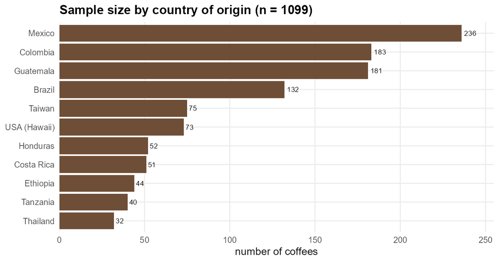

[figure not shown]

- Sample sizes are imbalanced (Mexico 236, Thailand 32).
- Total Cup Points are centered around 82, with most coffees between 80–85 and a small left tail of lower-scoring samples.

## Correlation Structure

[figure not shown]

- All six attributes are positively correlated (r between 0.54 and 0.85).
- A coffee scoring well on one attribute tends to score well on the others.
- This shared variation motivates **principal component analysis**.